# how-it-works

```python
import pandas as pd
from digits_module import Digit
from sample_class_module import Sample
from perspective_module import Perspective
from associations_module import Associations
```

We are building a one-shot image recognition algorithm that is explainable by design. If you are interested in contributing to this project, please read along.

So far, the first phase is almost done. In this part, I mainly focused on getting the algorithm to work on small dataset such as MNIST digits and the random doodles from the [test it page](https://www.xaenr.com/test-it) . If you are curious about how to submit samples for test, visit [this page](https://www.xaenr.com/how-to-test-it).

The next phase is scaling the project's capability such that it would work with bigger images.

In this discussion, I will be taking you through the classes, and the methods that you could use to experiment on what I have done and assuming you will be interested in contributing, add or modify a few things to make it more robust, efficient, and able to handle bigger images

The content provided here is broken down into four parts;

1. Get a two dimensional array to represent the sample
2. Transform the element values in the array
3. Generate an array of Perspectives corresponding to the original sample
4. Compare the arrays of perspectives. This is analogous to comparing the two samples

Throughout this discussion, I'll be using terms such as "sample", "element" a lot. Here's their definition;

- **sample**: a two dimensional array of numbers. Could be obtained from a picture or any other source
- **element**: a point in the two dimensional array. An example of an element is (1, 1)
- **angle**: I have used angle and orientation interchangeably. Whenever you see "angle" think of orientation. The "angle" as used in this work only shows how horizontal or vertical an element is. It makes no distinction of an angle being $45^\circ$ or $135^\circ$. Both are treated the same. I did that to make the algorithm robust with respect to image rotation

## Step 1: Get the two dimensional array

There's nothing much to say here.

For the website, these were the doodles. Soon, it will be big images. For testing, I used MNIST digits extensively. I developed two classes; **Digit** from *digits_module* that uses data from MNIST and **Sample** from *sample_class_module*. The **Digit** class was mainly used for testing and its use may not be needed past the first phase. Still, it will be heavily discussed here.

### 1.1 Getting a sample digit

The default digit is zero

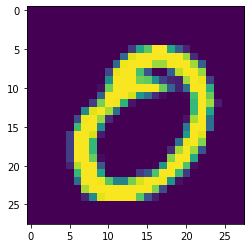

```python
my_digit = Digit()
my_digit.show()
```

You are allowed to pick a different digit

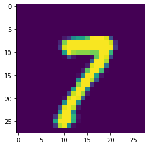

```python
my_digit = Digit(7)
my_digit.show()
```

Or a different sample of the same digit

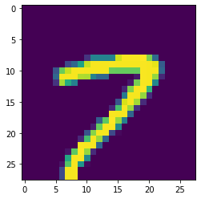

```python
my_digit = Digit(7, 10)
my_digit.show()
```

I should mention that I have created a lot of methods such as the *Digit.show()* used above so that anybody using the classes I created can have a visual representation of what they are doing. This is useful for examining the accuracy or appropriateness of whatever is being implemented

## Step 2: Transforming element values

Recall from [this discussion](https://xaenr.com/intuition) that I need to make the elements related in a way that forces them to be mapped in a new image to regions that keep them as close as they were in the original image. One of the things that I did to enable this is through transforming element values by calculating "angle". I have put it in quotes because it actually means **orientation**

Another thing that happens here is that I am discarding all elements that are not an edge. These elements do not provide any information. Discarding them reduces computational resources I need for this work (Yaay!)

The class **Sample** from *sample_class_module* provides a lot of functionalities for this. Here are some of the examples

```python
my_sample = Sample(my_digit.get_digit_array())
```

One of the main things that happen in the Sample object is conversion of the plain values into into values denoting orientation of the elements. When we do a `my_sample.show()`. We can see the orientation of each of the element making up the sample.

The dark purple are of horizontal orientation, while the yellow ones are of vertical orientation. The greenish values are of diagonal orientation

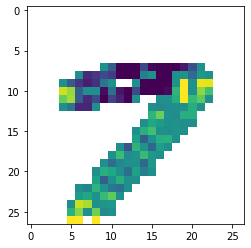

```python
my_sample.show()
```

There's also a method to show to show the distribution of the orientation values above. From the figure below, we can see that most of the elements have a diagonal orientation (around 50). An orientation value of 100 represents vertical, while 0 means it is horizontal. In that regard, we also see that there are more elements with a horizontal orientation compared to those with vertical ones

If you are interested in the whys and hows regarding my calculations of the orientation, check out [this](https://github.com/VinceXIV/x--arctan-test) and [this](https://github.com/VinceXIV/x--arctan-test-2) repos

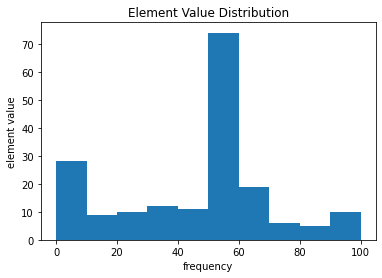

```python
my_sample.summarize()
```

We could also thinify our samples. I did this this reduce the number of elements I have to work with. One downside of doing this is that I lost information regarding the magnitude of "diagonalness" each elements were. By thinning, all elements are either vertical (orientation == 100), horizontal (orientation == 0), or diagonal (orientation == 50). All other values are, unfortunately, mapped into these three. I'm still working on ensuring this information is not lost

```python
my_sample = Sample(my_digit.get_digit_array(), thinify=True)
my_sample.show()
```

[output not shown]